# examples_1216

Let $f$ be a function. Consider the curve defined by the following equation:

$$y=2\cdot
f{\left[\frac{x+4}{5}\right]}-7$$

That curve can be interpreted as a transformation of the parent curve $b=f[a]$. What transformations, **and in what order**, would produce the daughter curve from the parent curve?

### Horizontal Transformations

- First
- Second

### Vertical Transformations

- First
- Second

The correct answers are:

- Horizontal transformations:
  - stretch by factor 5
  - shift left by distance 4
- Vertical transformations:
  - stretch by factor 2
  - shift down by distance 7

The horizontal transformations are determined by the operations inside the argument of the function. The vertical transformations are determined by the operations outside the function.

Notice, the horizontal transformations are kind of "backwards" in order and effect from what you'd expect based on PEMDAS. The vertical transformations are intuitive.

It is easiest to see why by setting the arguent equal to $a$. Start by writing down the given equation.

$$y=2\cdot
f{\left[\frac{x+4}{5}\right]}-7$$

Set the argument equal to $a$.

$$\frac{x+4}{5}=a$$

Solve the [two-step equation](https://chadworley.github.io/algtwo2026/u02/10_09/outhtml/EZ_two-step_equations.html).

$$x=5 a-4$$

Because $\frac{x+4}{5}$ equals $a$, we can substitute $a$ for the argument in our equation.

$$y=2\cdot
f{\left[a\right]}-7$$

Because $f(a)$ equals $b$, we can substitute $b$ for $f(a)$.

$$y=2\cdot b-7$$

Write the coordinate transformation (from the $x=$ formula and the $y=$ formula):

$$(a,b)\to\left(5 a-4~,~2\cdot
b-7\right)$$

Once the function transformations are expressed as a coordinate transformation, we can just follow the order of operations (PEMDAS), and the operations are all intuitive. Multiplication (by number more than 1) causes stretch; division causes shrink; addition or subtraction cause shifts. So, again, the correct answers are:

- Horizontal transformations:
  - stretch by factor 5
  - shift left by distance 4
- Vertical transformations:
  - stretch by factor 2
  - shift down by distance 7

Let $f$ be a function. Consider the curve defined by the following equation:

$$y=\frac{f{\left[\frac{x}{4}+3\right]}}{6}-2$$

That curve can be interpreted as a transformation of the parent curve $b=f[a]$. What transformations, **and in what order**, would produce the daughter curve from the parent curve?

### Horizontal Transformations

- First
- Second

### Vertical Transformations

- First
- Second

The correct answers are:

- Horizontal transformations:
  - shift left by distance 3
  - stretch by factor 4
- Vertical transformations:
  - shrink by factor 6
  - shift down by distance 2

The horizontal transformations are determined by the operations inside the argument of the function. The vertical transformations are determined by the operations outside the function.

Notice, the horizontal transformations are kind of "backwards" in order and effect from what you'd expect based on PEMDAS. The vertical transformations are intuitive.

It is easiest to see why by setting the arguent equal to $a$. Start by writing down the given equation.

$$y=\frac{f{\left[\frac{x}{4}+3\right]}}{6}-2$$

Set the argument equal to $a$.

$$\frac{x}{4}+3=a$$

Solve the [two-step equation](https://chadworley.github.io/algtwo2026/u02/10_09/outhtml/EZ_two-step_equations.html).

$$x=4\left(a-3\right)$$

Because $\frac{x}{4}+3$ equals $a$, we can substitute $a$ for the argument in our equation.

$$y=\frac{f{\left[a\right]}}{6}-2$$

Because $f(a)$ equals $b$, we can substitute $b$ for $f(a)$.

$$y=\frac{b}{6}-2$$

Write the coordinate transformation (from the $x=$ formula and the $y=$ formula):

$$(a,b)\to\left(4\left(a-3\right)~,~\frac{b}{6}-2\right)$$

Once the function transformations are expressed as a coordinate transformation, we can just follow the order of operations (PEMDAS), and the operations are all intuitive. Multiplication (by number more than 1) causes stretch; division causes shrink; addition or subtraction cause shifts. So, again, the correct answers are:

- Horizontal transformations:
  - shift left by distance 3
  - stretch by factor 4
- Vertical transformations:
  - shrink by factor 6
  - shift down by distance 2

Let $f$ be a function. Consider the curve defined by the following equation:

$$y=\frac{f{\left[\frac{x+2}{6}\right]}}{8}+3$$

That curve can be interpreted as a transformation of the parent curve $b=f[a]$. What transformations, **and in what order**, would produce the daughter curve from the parent curve?

### Horizontal Transformations

- First
- Second

### Vertical Transformations

- First
- Second

The correct answers are:

- Horizontal transformations:
  - stretch by factor 6
  - shift left by distance 2
- Vertical transformations:
  - shrink by factor 8
  - shift up by distance 3

The horizontal transformations are determined by the operations inside the argument of the function. The vertical transformations are determined by the operations outside the function.

Notice, the horizontal transformations are kind of "backwards" in order and effect from what you'd expect based on PEMDAS. The vertical transformations are intuitive.

It is easiest to see why by setting the arguent equal to $a$. Start by writing down the given equation.

$$y=\frac{f{\left[\frac{x+2}{6}\right]}}{8}+3$$

Set the argument equal to $a$.

$$\frac{x+2}{6}=a$$

Solve the [two-step equation](https://chadworley.github.io/algtwo2026/u02/10_09/outhtml/EZ_two-step_equations.html).

$$x=6 a-2$$

Because $\frac{x+2}{6}$ equals $a$, we can substitute $a$ for the argument in our equation.

$$y=\frac{f{\left[a\right]}}{8}+3$$

Because $f(a)$ equals $b$, we can substitute $b$ for $f(a)$.

$$y=\frac{b}{8}+3$$

Write the coordinate transformation (from the $x=$ formula and the $y=$ formula):

$$(a,b)\to\left(6
a-2~,~\frac{b}{8}+3\right)$$

Once the function transformations are expressed as a coordinate transformation, we can just follow the order of operations (PEMDAS), and the operations are all intuitive. Multiplication (by number more than 1) causes stretch; division causes shrink; addition or subtraction cause shifts. So, again, the correct answers are:

- Horizontal transformations:
  - stretch by factor 6
  - shift left by distance 2
- Vertical transformations:
  - shrink by factor 8
  - shift up by distance 3

Let $f$ be a function. Consider the curve defined by the following equation:

$$y=\frac{f{\left[\frac{x+9}{8}\right]}-4}{2}$$

That curve can be interpreted as a transformation of the parent curve $b=f[a]$. What transformations, **and in what order**, would produce the daughter curve from the parent curve?

### Horizontal Transformations

- First
- Second

### Vertical Transformations

- First
- Second

The correct answers are:

- Horizontal transformations:
  - stretch by factor 8
  - shift left by distance 9
- Vertical transformations:
  - shift down by distance 4
  - shrink by factor 2

The horizontal transformations are determined by the operations inside the argument of the function. The vertical transformations are determined by the operations outside the function.

Notice, the horizontal transformations are kind of "backwards" in order and effect from what you'd expect based on PEMDAS. The vertical transformations are intuitive.

It is easiest to see why by setting the arguent equal to $a$. Start by writing down the given equation.

$$y=\frac{f{\left[\frac{x+9}{8}\right]}-4}{2}$$

Set the argument equal to $a$.

$$\frac{x+9}{8}=a$$

Solve the [two-step equation](https://chadworley.github.io/algtwo2026/u02/10_09/outhtml/EZ_two-step_equations.html).

$$x=8 a-9$$

Because $\frac{x+9}{8}$ equals $a$, we can substitute $a$ for the argument in our equation.

$$y=\frac{f{\left[a\right]}-4}{2}$$

Because $f(a)$ equals $b$, we can substitute $b$ for $f(a)$.

$$y=\frac{b-4}{2}$$

Write the coordinate transformation (from the $x=$ formula and the $y=$ formula):

$$(a,b)\to\left(8
a-9~,~\frac{b-4}{2}\right)$$

Once the function transformations are expressed as a coordinate transformation, we can just follow the order of operations (PEMDAS), and the operations are all intuitive. Multiplication (by number more than 1) causes stretch; division causes shrink; addition or subtraction cause shifts. So, again, the correct answers are:

- Horizontal transformations:
  - stretch by factor 8
  - shift left by distance 9
- Vertical transformations:
  - shift down by distance 4
  - shrink by factor 2

Let $f$ be a function. Consider the curve defined by the following equation:

$$y=\frac{f{\left[\frac{x-4}{3}\right]}}{9}+2$$

That curve can be interpreted as a transformation of the parent curve $b=f[a]$. What transformations, **and in what order**, would produce the daughter curve from the parent curve?

### Horizontal Transformations

- First
- Second

### Vertical Transformations

- First
- Second

The correct answers are:

- Horizontal transformations:
  - stretch by factor 3
  - shift right by distance 4
- Vertical transformations:
  - shrink by factor 9
  - shift up by distance 2

The horizontal transformations are determined by the operations inside the argument of the function. The vertical transformations are determined by the operations outside the function.

Notice, the horizontal transformations are kind of "backwards" in order and effect from what you'd expect based on PEMDAS. The vertical transformations are intuitive.

It is easiest to see why by setting the arguent equal to $a$. Start by writing down the given equation.

$$y=\frac{f{\left[\frac{x-4}{3}\right]}}{9}+2$$

Set the argument equal to $a$.

$$\frac{x-4}{3}=a$$

Solve the [two-step equation](https://chadworley.github.io/algtwo2026/u02/10_09/outhtml/EZ_two-step_equations.html).

$$x=3 a+4$$

Because $\frac{x-4}{3}$ equals $a$, we can substitute $a$ for the argument in our equation.

$$y=\frac{f{\left[a\right]}}{9}+2$$

Because $f(a)$ equals $b$, we can substitute $b$ for $f(a)$.

$$y=\frac{b}{9}+2$$

Write the coordinate transformation (from the $x=$ formula and the $y=$ formula):

$$(a,b)\to\left(3
a+4~,~\frac{b}{9}+2\right)$$

Once the function transformations are expressed as a coordinate transformation, we can just follow the order of operations (PEMDAS), and the operations are all intuitive. Multiplication (by number more than 1) causes stretch; division causes shrink; addition or subtraction cause shifts. So, again, the correct answers are:

- Horizontal transformations:
  - stretch by factor 3
  - shift right by distance 4
- Vertical transformations:
  - shrink by factor 9
  - shift up by distance 2

A possible parameterization to show transformed base-2 exponential functions is:

$$y~=~ m \cdot
2^{\frac{1}{p}(x-h)}+k$$

With this form, the stretches happen before the shifts. The stretch factors are $p$ horizontally and $m$ vertically. The shift terms are $h$ horizontally and $k$ vertically.

If $m$ and $p$ are restricted to $-1$ and $1$, then the only "stretches" are reflections. If $m$ is negative, then there is a vertical reflection over the $x$ axis. If $p$ is negative, then there is a horizontal reflection over the $y$ axis.

By randomly selecting $-1$ or $1$ for $m$ and $p$, and random integers for $h$ and $k$, the following blue curve is defined. (And the grey curve is the parent $y=2^x$.)

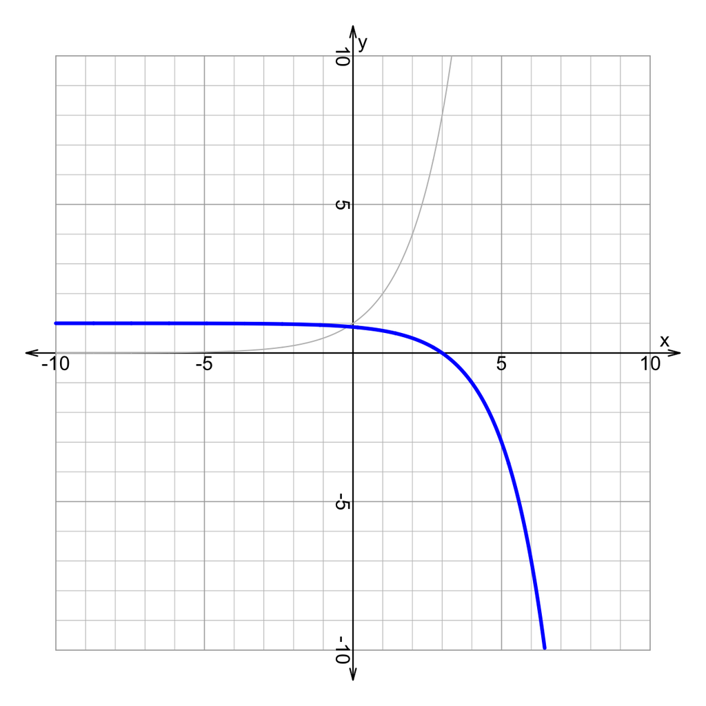

Find the parameters.

- $m=$
- $p=$
- $h=$
- $k=$

I'd recommend setting up the following equation in [Desmos](https://www.desmos.com/calculator). Let sliders represent the parameters, and see what each parameter does as you vary it.

$$y~=~ m \cdot
2^{\frac{1}{p}(x-h)}+k$$

It will help to first identify the reflections. There is a vertical reflection only, so $m=-1$ and $p=1$. It is helpful to sketch the reflected parent function. In orange, I will sketch the reflected (but unshifted) transformation.

It also helps to sketch the horizontal asymptotes. Also, you'll want to identify the point that is either 1 above or 1 below the asymptote. I've marked this point on both the orange and blue curves.

And finally, you'll want to identify the displacements from the orange dot to the blue dot. These horizontal and vertical displacements show the values of $h$ and $k$.

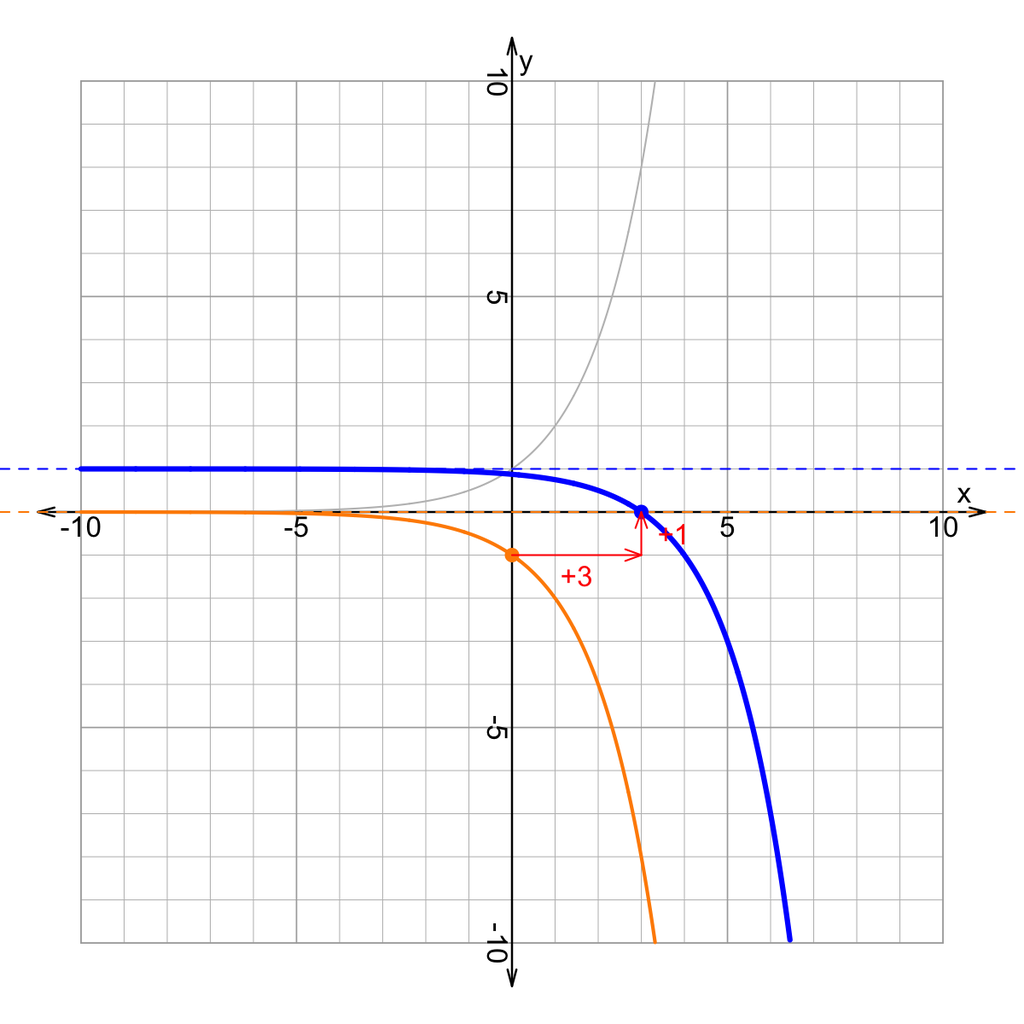

- $m=-1$
- $p=1$
- $h=3$
- $k=1$

And, thus, the equation of the blue curve is:

$$y=-2^{x-3}+1$$

A possible parameterization to show transformed base-2 exponential functions is:

$$y~=~ m \cdot
2^{\frac{1}{p}(x-h)}+k$$

With this form, the stretches happen before the shifts. The stretch factors are $p$ horizontally and $m$ vertically. The shift terms are $h$ horizontally and $k$ vertically.

If $m$ and $p$ are restricted to $-1$ and $1$, then the only "stretches" are reflections. If $m$ is negative, then there is a vertical reflection over the $x$ axis. If $p$ is negative, then there is a horizontal reflection over the $y$ axis.

By randomly selecting $-1$ or $1$ for $m$ and $p$, and random integers for $h$ and $k$, the following blue curve is defined. (And the grey curve is the parent $y=2^x$.)

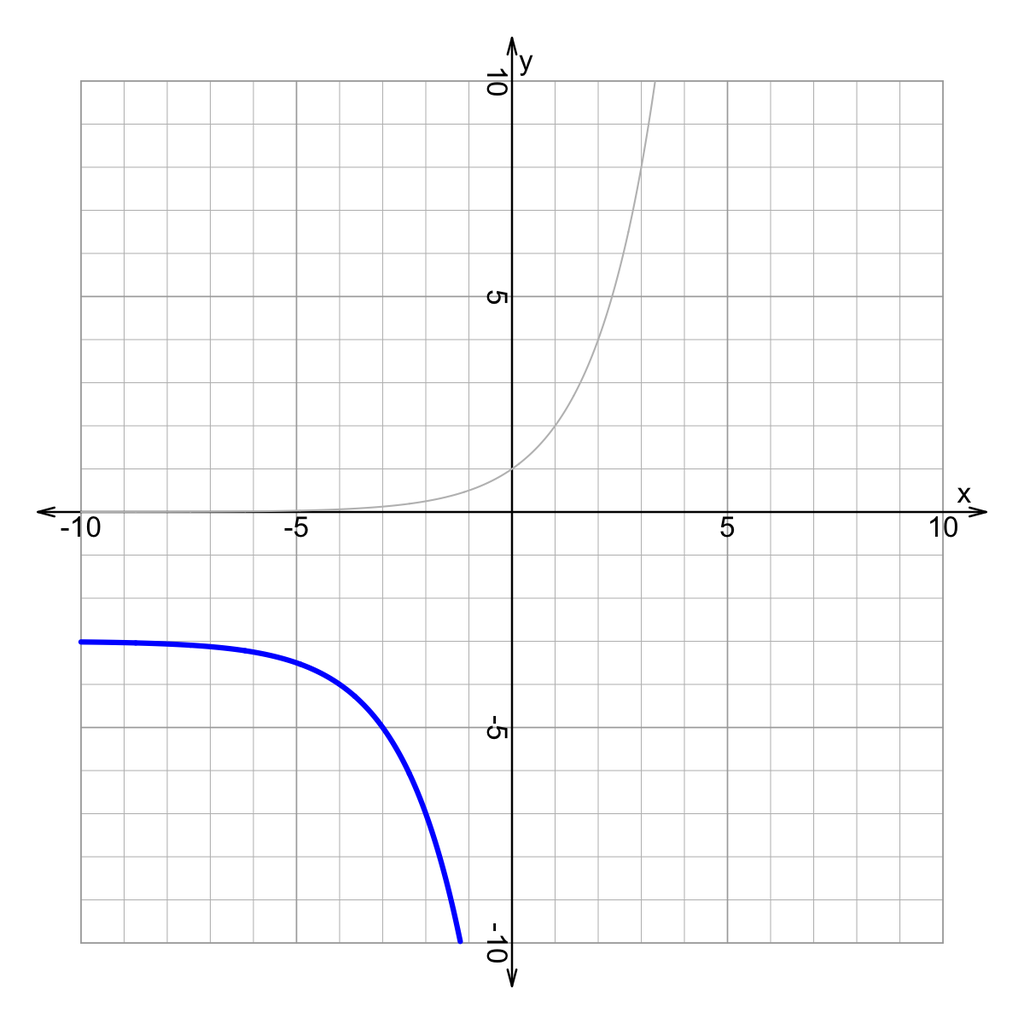

Find the parameters.

- $m=$
- $p=$
- $h=$
- $k=$

I'd recommend setting up the following equation in [Desmos](https://www.desmos.com/calculator). Let sliders represent the parameters, and see what each parameter does as you vary it.

$$y~=~ m \cdot
2^{\frac{1}{p}(x-h)}+k$$

It will help to first identify the reflections. There is a vertical reflection only, so $m=-1$ and $p=1$. It is helpful to sketch the reflected parent function. In orange, I will sketch the reflected (but unshifted) transformation.

It also helps to sketch the horizontal asymptotes. Also, you'll want to identify the point that is either 1 above or 1 below the asymptote. I've marked this point on both the orange and blue curves.

And finally, you'll want to identify the displacements from the orange dot to the blue dot. These horizontal and vertical displacements show the values of $h$ and $k$.

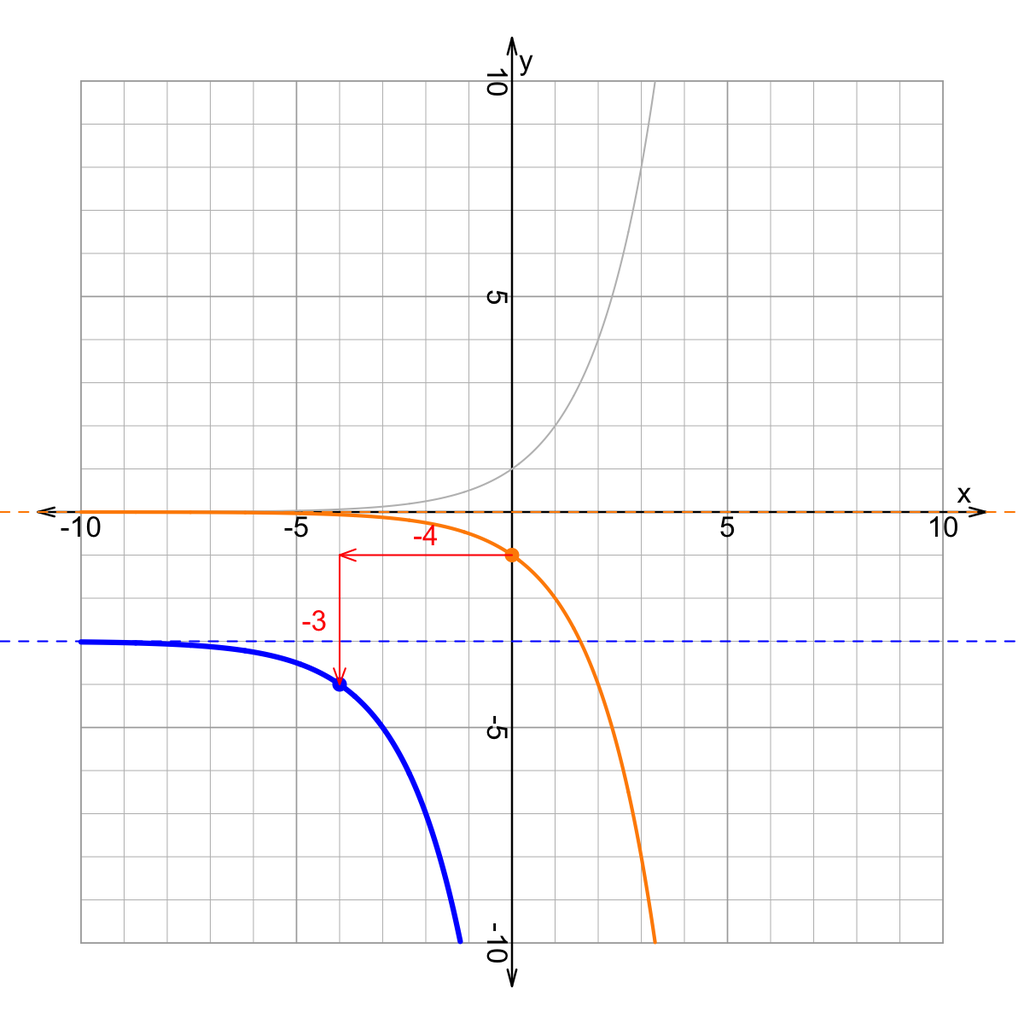

- $m=-1$
- $p=1$
- $h=-4$
- $k=-3$

And, thus, the equation of the blue curve is:

$$y=-2^{x+4}-3$$

A possible parameterization to show transformed base-2 exponential functions is:

$$y~=~ m \cdot
2^{\frac{1}{p}(x-h)}+k$$

With this form, the stretches happen before the shifts. The stretch factors are $p$ horizontally and $m$ vertically. The shift terms are $h$ horizontally and $k$ vertically.

If $m$ and $p$ are restricted to $-1$ and $1$, then the only "stretches" are reflections. If $m$ is negative, then there is a vertical reflection over the $x$ axis. If $p$ is negative, then there is a horizontal reflection over the $y$ axis.

By randomly selecting $-1$ or $1$ for $m$ and $p$, and random integers for $h$ and $k$, the following blue curve is defined. (And the grey curve is the parent $y=2^x$.)

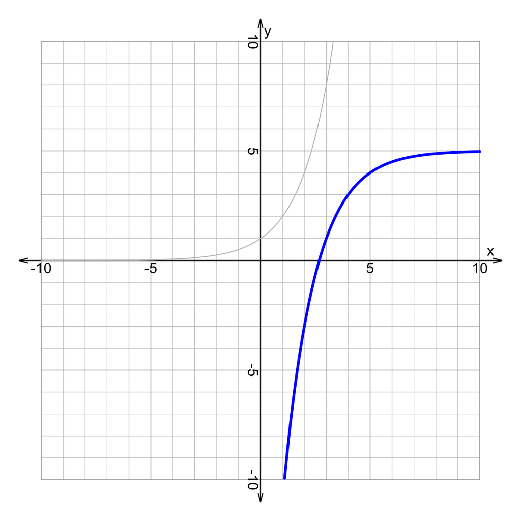

Find the parameters.

- $m=$
- $p=$
- $h=$
- $k=$

I'd recommend setting up the following equation in [Desmos](https://www.desmos.com/calculator). Let sliders represent the parameters, and see what each parameter does as you vary it.

$$y~=~ m \cdot
2^{\frac{1}{p}(x-h)}+k$$

It will help to first identify the reflections. There are both vertical and horizontal reflections, so $m=-1$ and $p=-1$. It is helpful to sketch the reflected parent function. In orange, I will sketch the reflected (but unshifted) transformation.

It also helps to sketch the horizontal asymptotes. Also, you'll want to identify the point that is either 1 above or 1 below the asymptote. I've marked this point on both the orange and blue curves.

And finally, you'll want to identify the displacements from the orange dot to the blue dot. These horizontal and vertical displacements show the values of $h$ and $k$.

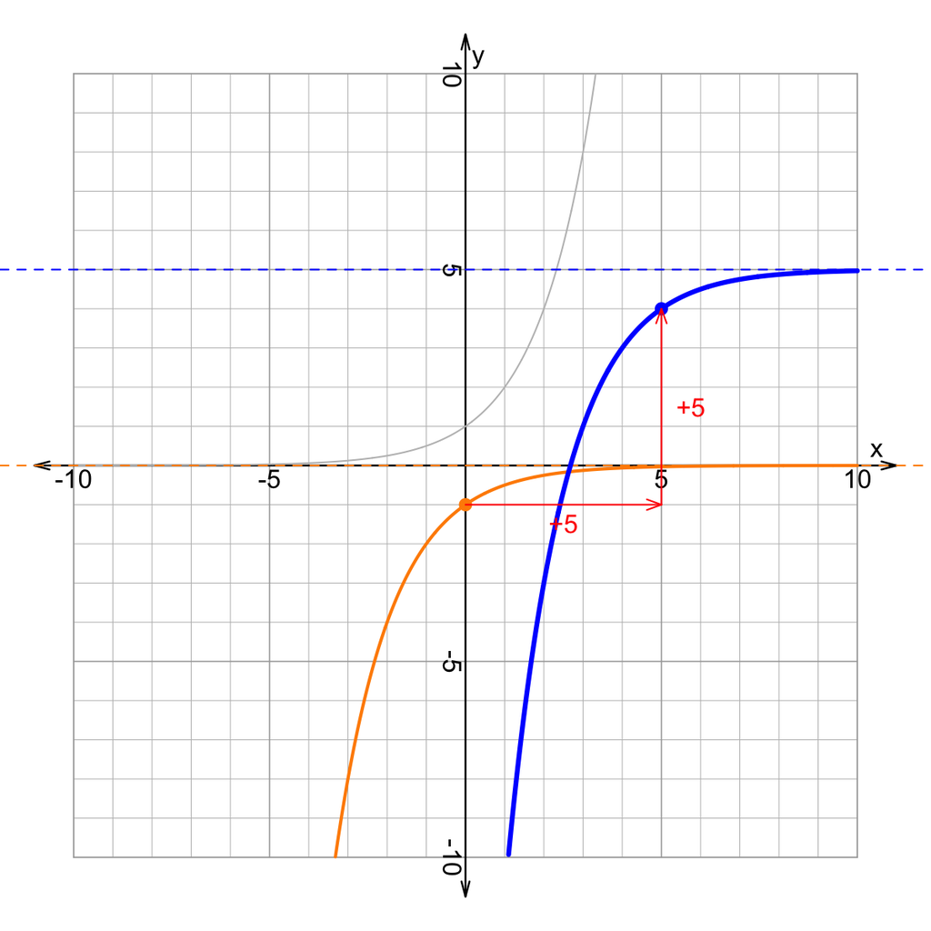

- $m=-1$
- $p=-1$
- $h=5$
- $k=5$

And, thus, the equation of the blue curve is:

$$y=-2^{-(x-5)}+5$$

A possible parameterization to show transformed base-2 exponential functions is:

$$y~=~ m \cdot
2^{\frac{1}{p}(x-h)}+k$$

With this form, the stretches happen before the shifts. The stretch factors are $p$ horizontally and $m$ vertically. The shift terms are $h$ horizontally and $k$ vertically.

If $m$ and $p$ are restricted to $-1$ and $1$, then the only "stretches" are reflections. If $m$ is negative, then there is a vertical reflection over the $x$ axis. If $p$ is negative, then there is a horizontal reflection over the $y$ axis.

By randomly selecting $-1$ or $1$ for $m$ and $p$, and random integers for $h$ and $k$, the following blue curve is defined. (And the grey curve is the parent $y=2^x$.)

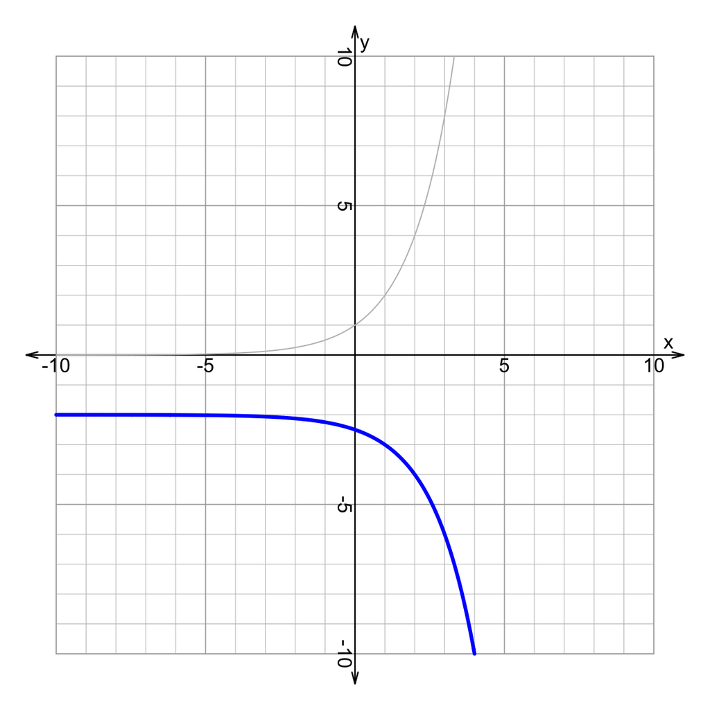

Find the parameters.

- $m=$
- $p=$
- $h=$
- $k=$

I'd recommend setting up the following equation in [Desmos](https://www.desmos.com/calculator). Let sliders represent the parameters, and see what each parameter does as you vary it.

$$y~=~ m \cdot
2^{\frac{1}{p}(x-h)}+k$$

It will help to first identify the reflections. There is a vertical reflection only, so $m=-1$ and $p=1$. It is helpful to sketch the reflected parent function. In orange, I will sketch the reflected (but unshifted) transformation.

It also helps to sketch the horizontal asymptotes. Also, you'll want to identify the point that is either 1 above or 1 below the asymptote. I've marked this point on both the orange and blue curves.

And finally, you'll want to identify the displacements from the orange dot to the blue dot. These horizontal and vertical displacements show the values of $h$ and $k$.

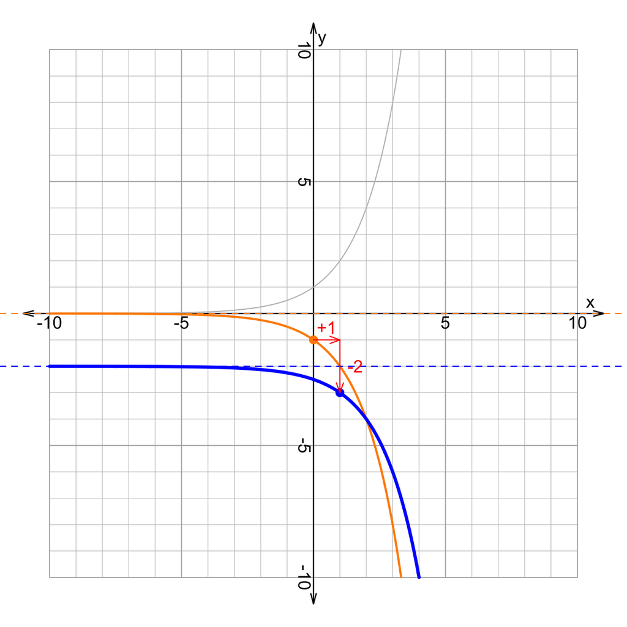

- $m=-1$
- $p=1$
- $h=1$
- $k=-2$

And, thus, the equation of the blue curve is:

$$y=-2^{x-1}-2$$

A possible parameterization to show transformed base-2 exponential functions is:

$$y~=~ m \cdot
2^{\frac{1}{p}(x-h)}+k$$

With this form, the stretches happen before the shifts. The stretch factors are $p$ horizontally and $m$ vertically. The shift terms are $h$ horizontally and $k$ vertically.

If $m$ and $p$ are restricted to $-1$ and $1$, then the only "stretches" are reflections. If $m$ is negative, then there is a vertical reflection over the $x$ axis. If $p$ is negative, then there is a horizontal reflection over the $y$ axis.

By randomly selecting $-1$ or $1$ for $m$ and $p$, and random integers for $h$ and $k$, the following blue curve is defined. (And the grey curve is the parent $y=2^x$.)

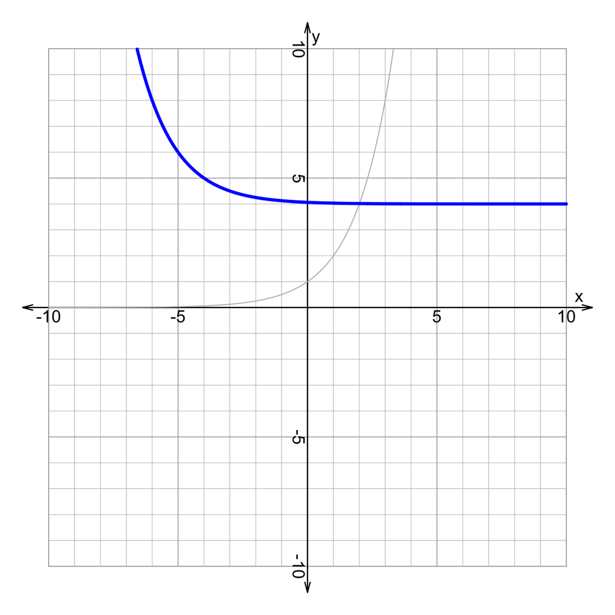

Find the parameters.

- $m=$
- $p=$
- $h=$
- $k=$

I'd recommend setting up the following equation in [Desmos](https://www.desmos.com/calculator). Let sliders represent the parameters, and see what each parameter does as you vary it.

$$y~=~ m \cdot
2^{\frac{1}{p}(x-h)}+k$$

It will help to first identify the reflections. There is a horizontal reflection only, so $m=1$ and $p=-1$. It is helpful to sketch the reflected parent function. In orange, I will sketch the reflected (but unshifted) transformation.

It also helps to sketch the horizontal asymptotes. Also, you'll want to identify the point that is either 1 above or 1 below the asymptote. I've marked this point on both the orange and blue curves.

And finally, you'll want to identify the displacements from the orange dot to the blue dot. These horizontal and vertical displacements show the values of $h$ and $k$.

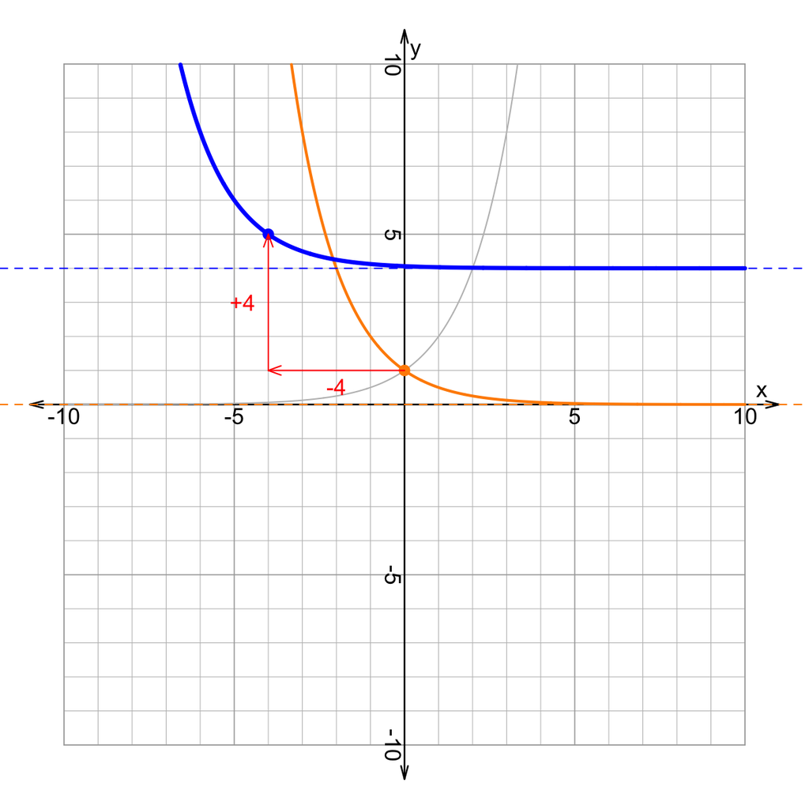

- $m=1$
- $p=-1$
- $h=-4$
- $k=4$

And, thus, the equation of the blue curve is:

$$y=2^{-(x+4)}+4$$